# Red Wine Exploration by Zhang Guanghui

# Univariate Plots Section

### Study the basic information of the dataset

### a) Rows and colums of dataset

```
## [1] 1599
```

```
## [1] 13
```

### b) str of dataset

```
## 'data.frame':    1599 obs. of  13 variables:
##  $ X                   : int  1 2 3 4 5 6 7 8 9 10 ...
##  $ fixed.acidity       : num  7.4 7.8 7.8 11.2 7.4 7.4 7.9 7.3 7.8 7.5 ...
##  $ volatile.acidity    : num  0.7 0.88 0.76 0.28 0.7 0.66 0.6 0.65 0.58 0.5 ...
##  $ citric.acid         : num  0 0 0.04 0.56 0 0 0.06 0 0.02 0.36 ...
##  $ residual.sugar      : num  1.9 2.6 2.3 1.9 1.9 1.8 1.6 1.2 2 6.1 ...
##  $ chlorides           : num  0.076 0.098 0.092 0.075 0.076 0.075 0.069 0.065 0.073 0.071 ...
##  $ free.sulfur.dioxide : num  11 25 15 17 11 13 15 15 9 17 ...
##  $ total.sulfur.dioxide: num  34 67 54 60 34 40 59 21 18 102 ...
##  $ density             : num  0.998 0.997 0.997 0.998 0.998 ...
##  $ pH                  : num  3.51 3.2 3.26 3.16 3.51 3.51 3.3 3.39 3.36 3.35 ...
##  $ sulphates           : num  0.56 0.68 0.65 0.58 0.56 0.56 0.46 0.47 0.57 0.8 ...
##  $ alcohol             : num  9.4 9.8 9.8 9.8 9.4 9.4 9.4 10 9.5 10.5 ...
##  $ quality             : int  5 5 5 6 5 5 5 7 7 5 ...
```

### c) names of variables in dataset

```
##  [1] "X"                    "fixed.acidity"        "volatile.acidity"
##  [4] "citric.acid"          "residual.sugar"       "chlorides"
##  [7] "free.sulfur.dioxide"  "total.sulfur.dioxide" "density"
## [10] "pH"                   "sulphates"            "alcohol"
## [13] "quality"
```

### d) head of dataset

```
##   X fixed.acidity volatile.acidity citric.acid residual.sugar chlorides
## 1 1           7.4             0.70        0.00            1.9     0.076
## 2 2           7.8             0.88        0.00            2.6     0.098
## 3 3           7.8             0.76        0.04            2.3     0.092
## 4 4          11.2             0.28        0.56            1.9     0.075
## 5 5           7.4             0.70        0.00            1.9     0.076
## 6 6           7.4             0.66        0.00            1.8     0.075
##   free.sulfur.dioxide total.sulfur.dioxide density   pH sulphates alcohol
## 1                  11                   34  0.9978 3.51      0.56     9.4
## 2                  25                   67  0.9968 3.20      0.68     9.8
## 3                  15                   54  0.9970 3.26      0.65     9.8
## 4                  17                   60  0.9980 3.16      0.58     9.8
## 5                  11                   34  0.9978 3.51      0.56     9.4
## 6                  13                   40  0.9978 3.51      0.56     9.4
##   quality
## 1       5
## 2       5
## 3       5
## 4       6
## 5       5
## 6       5
```

### e) summary of red wine quality

```
##        X          fixed.acidity   volatile.acidity  citric.acid
##  Min.   :   1.0   Min.   : 4.60   Min.   :0.1200   Min.   :0.000
##  1st Qu.: 400.5   1st Qu.: 7.10   1st Qu.:0.3900   1st Qu.:0.090
##  Median : 800.0   Median : 7.90   Median :0.5200   Median :0.260
##  Mean   : 800.0   Mean   : 8.32   Mean   :0.5278   Mean   :0.271
##  3rd Qu.:1199.5   3rd Qu.: 9.20   3rd Qu.:0.6400   3rd Qu.:0.420
##  Max.   :1599.0   Max.   :15.90   Max.   :1.5800   Max.   :1.000
##  residual.sugar     chlorides       free.sulfur.dioxide
##  Min.   : 0.900   Min.   :0.01200   Min.   : 1.00
##  1st Qu.: 1.900   1st Qu.:0.07000   1st Qu.: 7.00
##  Median : 2.200   Median :0.07900   Median :14.00
##  Mean   : 2.539   Mean   :0.08747   Mean   :15.87
##  3rd Qu.: 2.600   3rd Qu.:0.09000   3rd Qu.:21.00
##  Max.   :15.500   Max.   :0.61100   Max.   :72.00
##  total.sulfur.dioxide    density             pH          sulphates
##  Min.   :  6.00       Min.   :0.9901   Min.   :2.740   Min.   :0.3300
##  1st Qu.: 22.00       1st Qu.:0.9956   1st Qu.:3.210   1st Qu.:0.5500
##  Median : 38.00       Median :0.9968   Median :3.310   Median :0.6200
##  Mean   : 46.47       Mean   :0.9967   Mean   :3.311   Mean   :0.6581
##  3rd Qu.: 62.00       3rd Qu.:0.9978   3rd Qu.:3.400   3rd Qu.:0.7300
##  Max.   :289.00       Max.   :1.0037   Max.   :4.010   Max.   :2.0000
##     alcohol         quality
##  Min.   : 8.40   Min.   :3.000
##  1st Qu.: 9.50   1st Qu.:5.000
##  Median :10.20   Median :6.000
##  Mean   :10.42   Mean   :5.636
##  3rd Qu.:11.10   3rd Qu.:6.000
##  Max.   :14.90   Max.   :8.000
```

— The quality of red wine ranges from 3 to 8. The mean is 5.636 and the median is 6.

## f) histogram plots of all features

Plot the histogram plots of all features. Investigate the characteristics of the distribution of each one.

### f.1) histogram of red wine quality

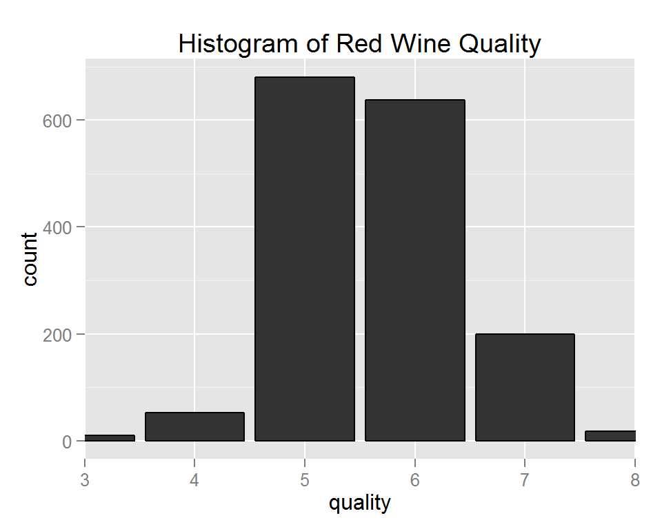

Six quality score is observed in the dataset. The histogram shows that most of quality is 5 or 6, while quality==3 and quality ==8 are very few. how many red wine with quality >=5 and <= 6 ?

```r
# get the percentage of rows with quality above 5 and below 6
as.numeric(n_mid)/nrow(redwine)
```

```
[1] 0.8248906
```

— 82% of redwine is has quality 5 or 6. It wil be very intersting to invesigate why some wine has distinctively high or low quality.

### f.2) histogram of citric.acid

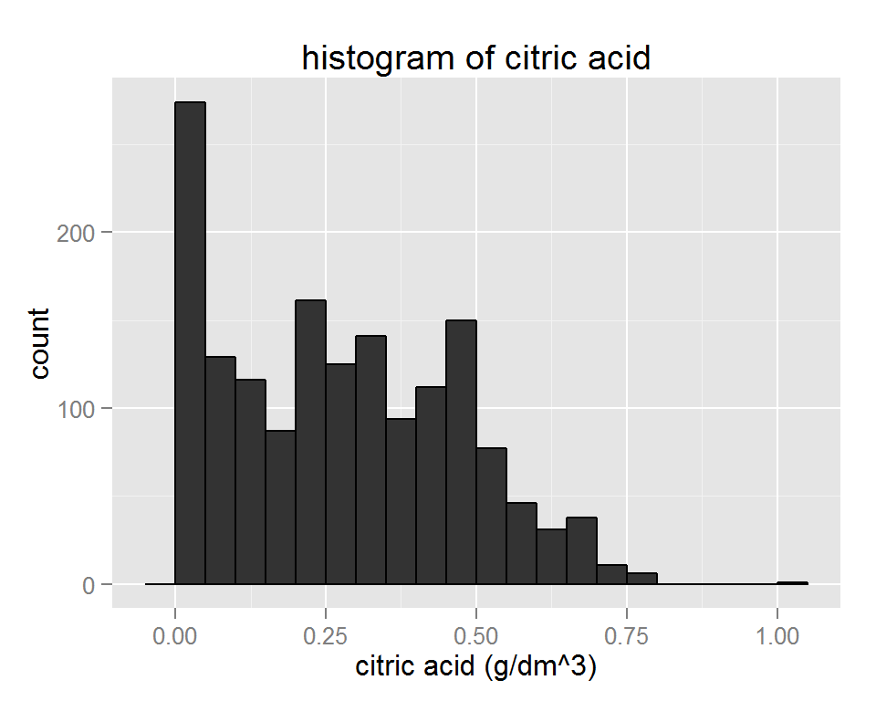

This histogram is positively skewed. The count of citric acid starts to descend after 0.50. Change the binwith to see more detailed information. Count the rows of data with citric acid = 0

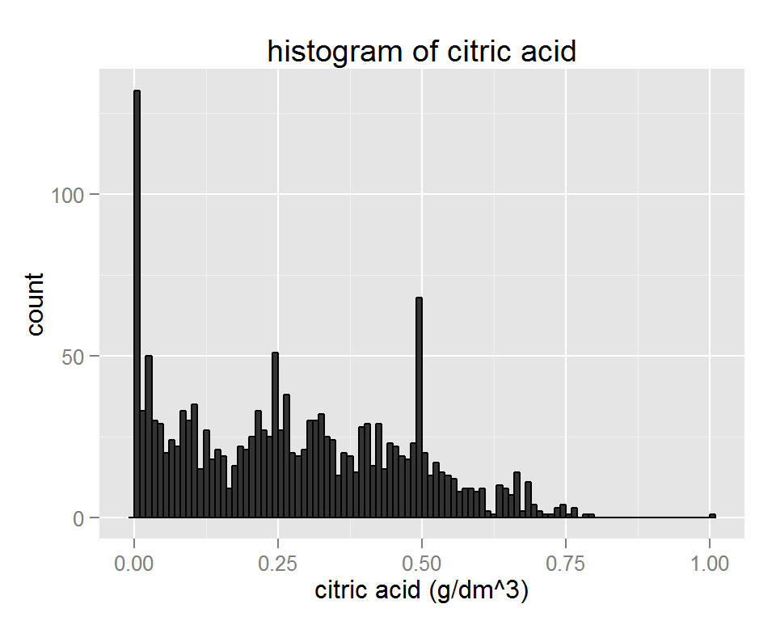

```
    n
1 132
```

— Changing binwidth shows that the citric.acid is very dispersed. 132 rows of data has citric acid 0. There are three major peaks at 0, 0.25, and 0.50.

### f.3) histogram of residual.sugar

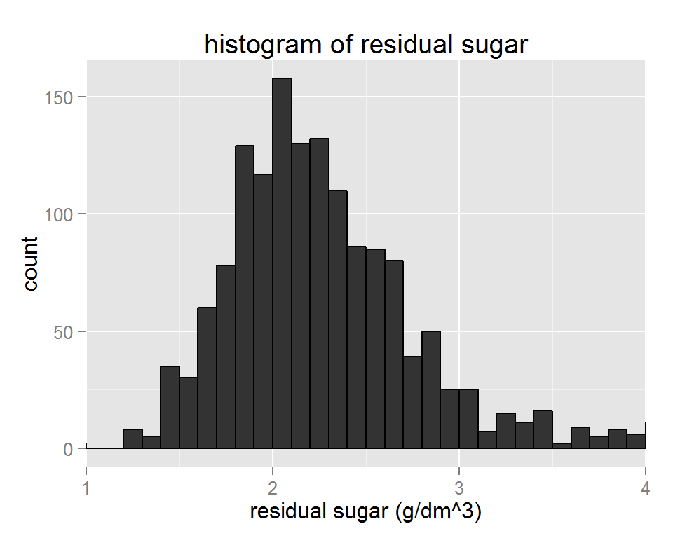

This histogram appears quite normally distributed. Get the summary of the feature residual sugar

```
   Min. 1st Qu.  Median    Mean 3rd Qu.    Max.
  0.900   1.900   2.200   2.539   2.600  15.500
```

— The histogram shows that very few wines have residual sugar over 4. The maximum residual sugar content is as high as 15.5

### f.4) histogram of sulphates

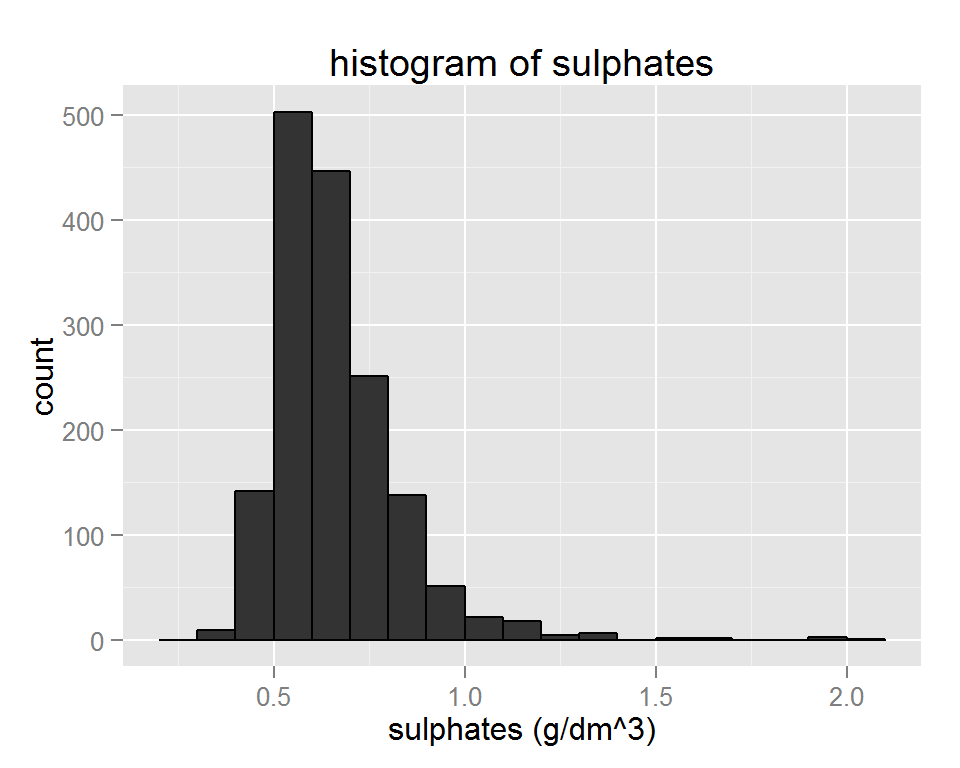

The histogram seems to be normally distributed. Change the bin width and x limits to check details.

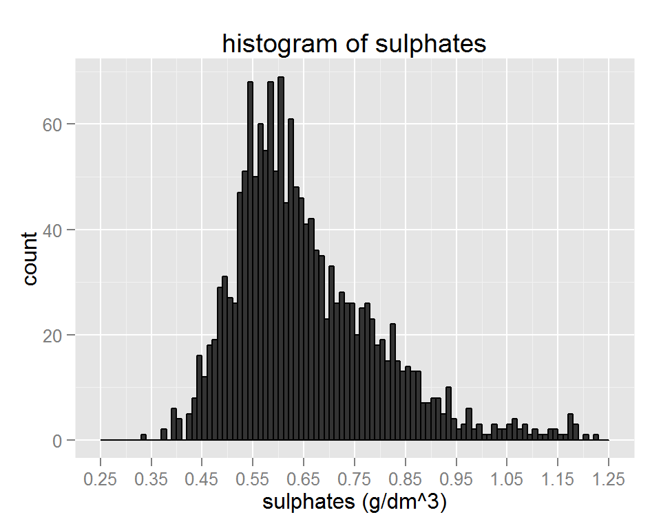

— The hisogram of sulphates show that very red wine has sulphates over 0.95. The major is between 0.35 and 0.95

### f.5) histogram of total.sulfur.dioxide

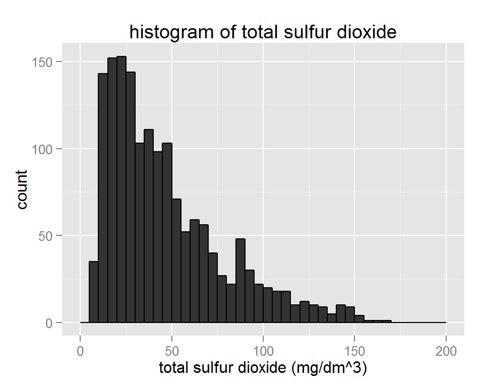

The distribution is positively skewed. Log-transform the x axis to see the distribution.

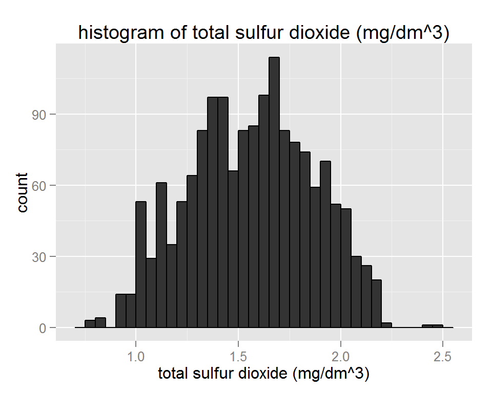

— The Log-transformed plot appears to be normally distributed. The majority is between 1.0 and 2.25.

### f.6) histogram of alcohol

See the distribution of alcohol with different binwidth.

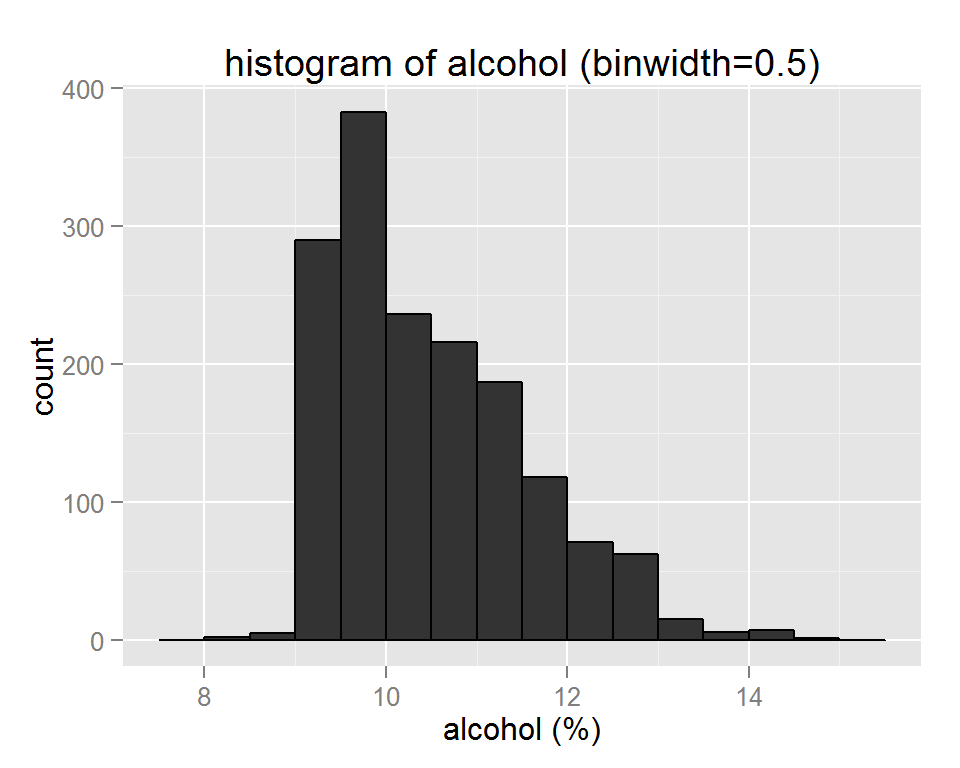

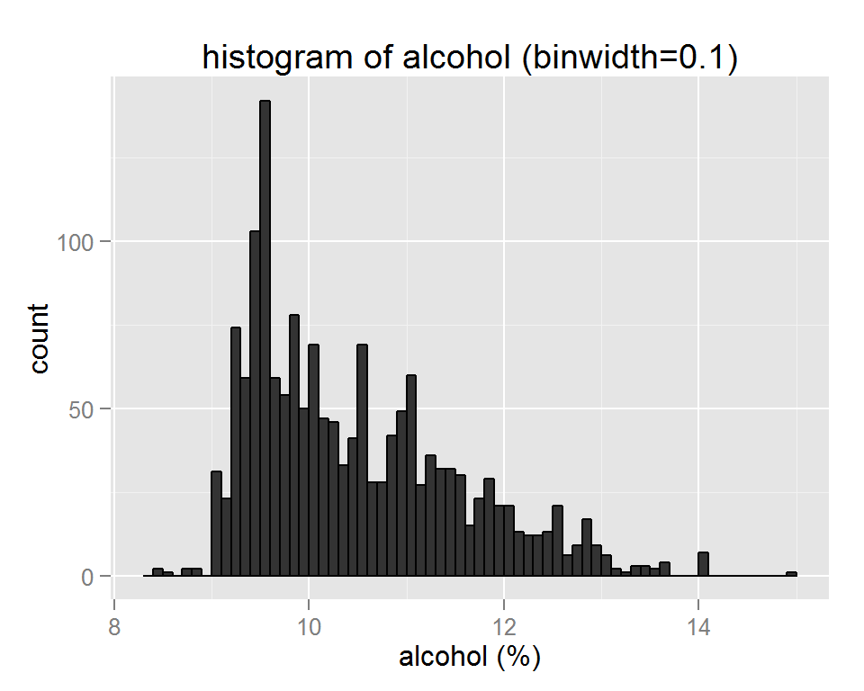

— Changing the binwidth reveals that the histogram plot of alcohol is positively skewed. Log transform the x axis

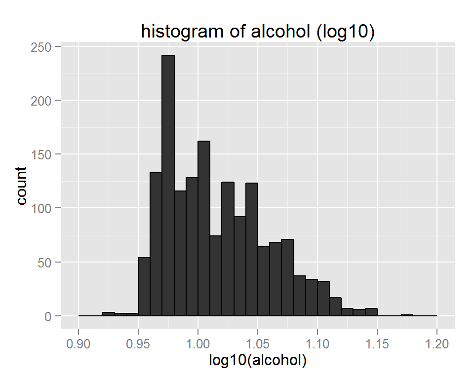

— The log-transformed plot shows that the majority is between 0.95 and 1.1, the peak is around 0.975.

### f.7) histogram of ph

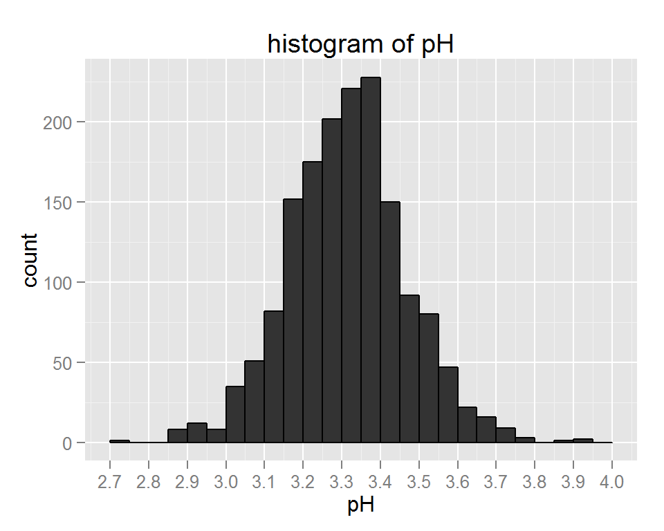

# Univariate Analysis

### What is the structure of your dataset?

— There are 1599 observations of data with 12 features, including “fixed.acidity”,“volatile.acidity”,“citric.acid”,“residual.sugar”, “chlorides”, “free.sulfur.dioxide”, “total.sulfur.dioxide”, “density”, “pH”, “sulphates”, “alcohol”, “quality”. The variable “quality” is an ordered factor variable: quality: 0-10 (worst —-> best). Most of redwines are of quality from 5-7.

### What is/are the main feature(s) of interest in your dataset?

— It will be impossible for a single variable to determine the quality of red wine, instead the combination and balance of different variables are the main factors. The quality is based on the smell, color, taste of the wine, with which the most determinant variables must be related. So I think the major features influencing includes citric acid, sulphates, alcohol.

### What other features in the dataset do you think will help support your investigation into your feature(s) of interest?

— I also think residual sugar, acidity, and chloride will possibly contribute to the quality of wine. I would like to assume residual sugar would probably contribute most at first. But it needs to be confirmed in the following investigation.

### Did you create any new variables from existing variables in the dataset?

— No. I did not create a new variables.

### Of the features you investigated, were there any unusual distributions? Did you perform any operations on the data to tidy, adjust, or change the form of the data? If so, why did you do this?

— 1. The histogram of residual sugar and sulfates indicates that some wine has a very high sugar content. So I use coord_cartesian to limit the x axis range. — 2. The rightly skewed histogram of total.sulfur.dioxide and alchohol are log-transformed.

# Bivariate Plots Section

- Split the data into two parts,
- Subset 1000 rows of data,
- plot ggpair figures

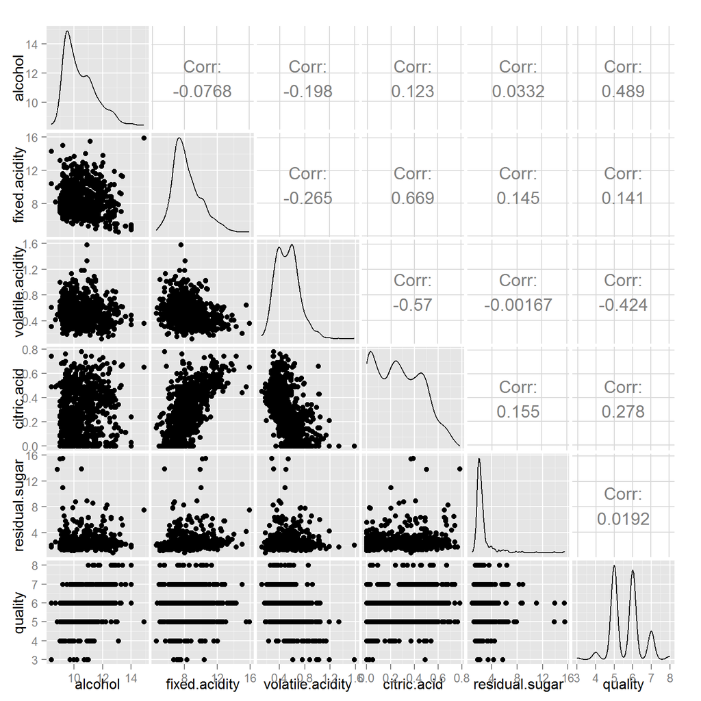

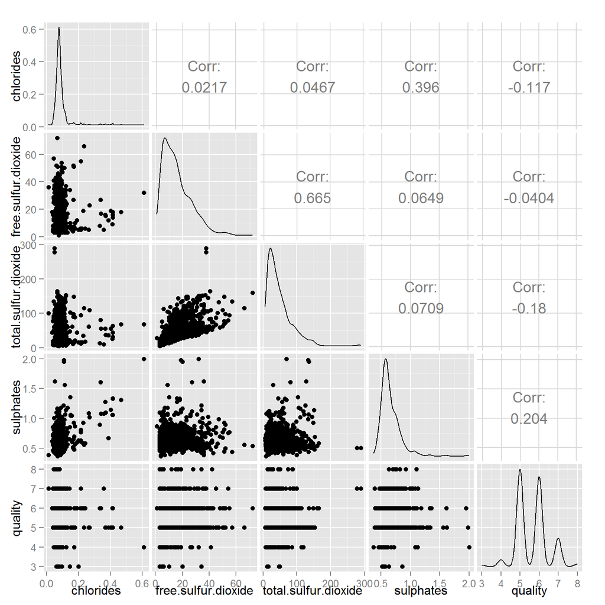

— In the ggpair figures, all plots of quality vs. other variabls appear to be horizontal strip. Closer investigation at the scatter plots involving quality is needed.

### Investigate what are the features influencing quality

— Create ordered factor variable quality.factor

— Group redwine by quality.factor

— Get the mean of other features

The code is as follow:

```r
redwine$quality.factor <- factor(redwine$quality)

redwine_grouped <- redwine %>%
  group_by(quality.factor) %>%
  summarize(mean_alcohol = round(mean(alcohol), 3),
            mean_vol_acid = round(mean(volatile.acidity), 3),
            mean_fix_acid = round(mean(fixed.acidity),3),
            mean_citric_acid = round(mean(citric.acid), 3),
            mean_sugar = round(mean(residual.sugar), 3),
            mean_chlorides = round(mean(chlorides),3),
            mean_free_sulfur = round(mean(free.sulfur.dioxide),3),
            mean_total_sulfur = round(mean(total.sulfur.dioxide), 3),
            mean_sulphates = round(mean(sulphates), 3),
            mean_ph = round(mean(pH), 3),
            mean_density = round(mean(density), 3),
            n=n())
```

### 1. quality against alcohol

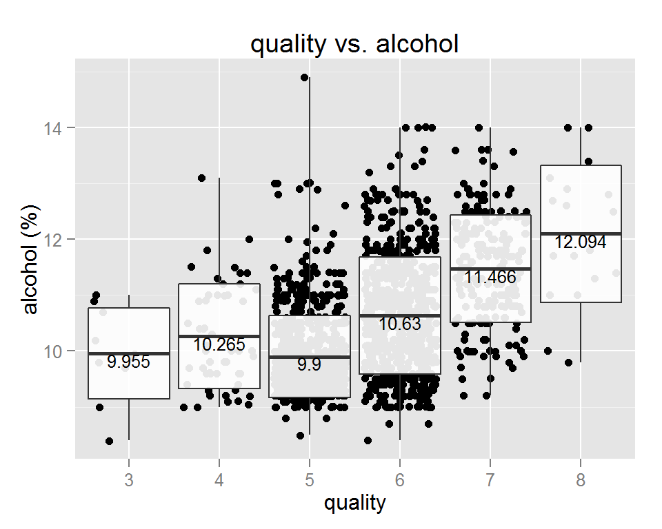

— The scatter plot of quality vs alcohol shows that high alcohol red wine has higher quality score. Red wine below the mean quality has alcohol around 10, while red wine above mean quality has obvious higher alcohol.

### 2. quality against volatile.acidity and fixed.acidity

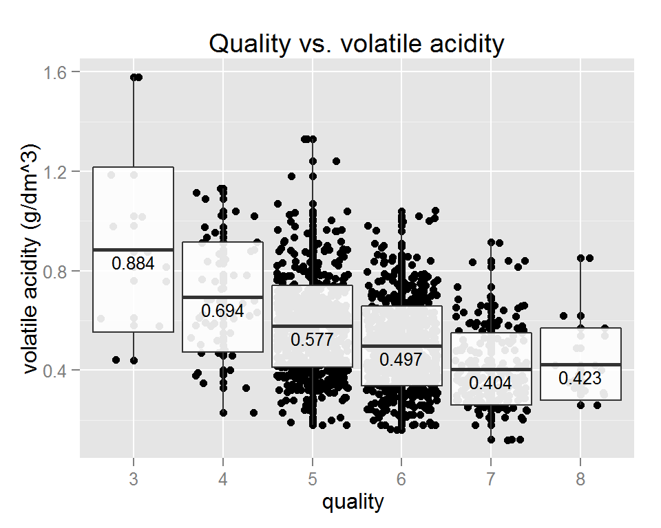

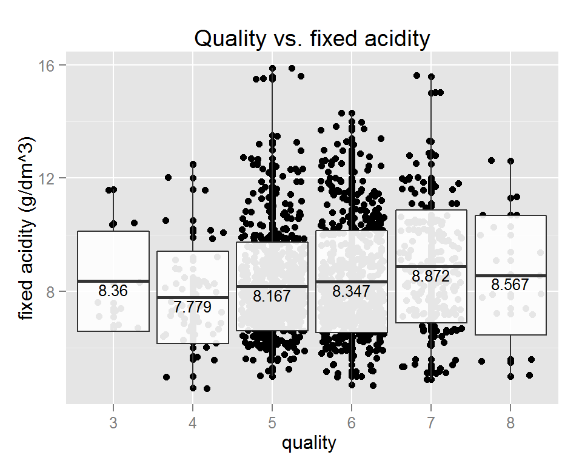

— The scatter plot of quality vs volatile acidity not only shows all the volatible acidity of each quality, but also shows the mean volatile acidity. High quality red wines appears to have smaller volatile acidity, except the red wines with highest quality 8. However, the relationship between quality and fixed.acidity is more complex.

### 3. Plot quality against citric acid

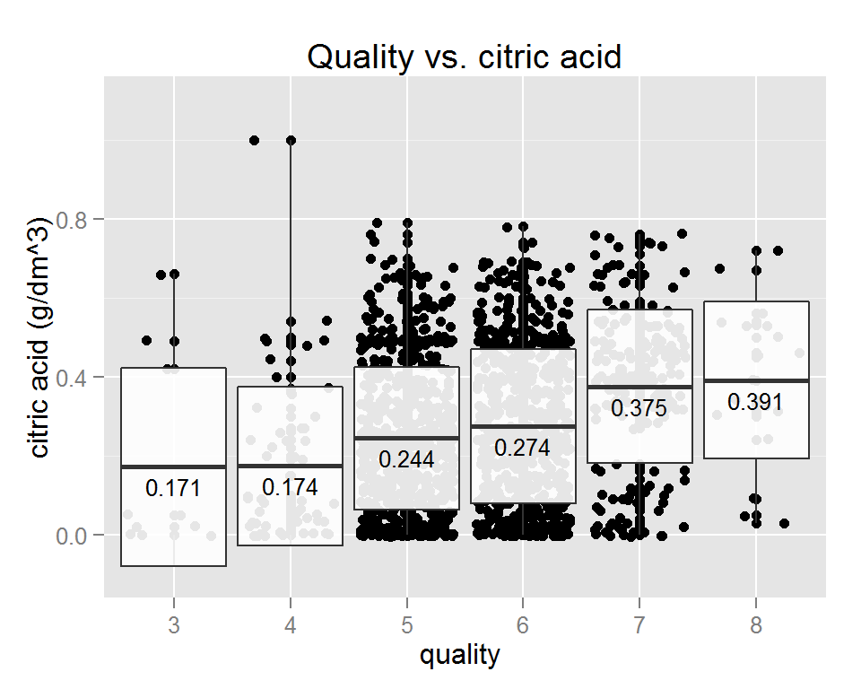

— The plot shows that high-quality red wine tends to have high citric acid. But citric acid is not a detrminant factor. There is one point with citric acid 1 but with quality only 4.

### 4. quality against residual.sugar

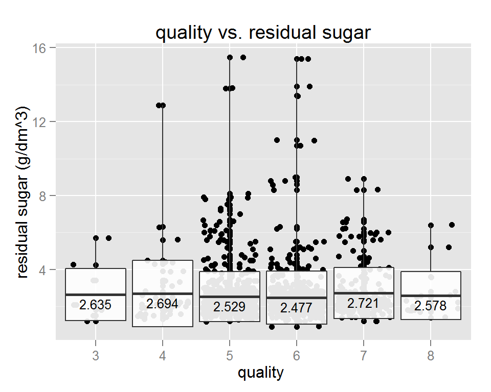

— According to the figure, no much differences among mean residual sugar

### 5. quality against chlorides

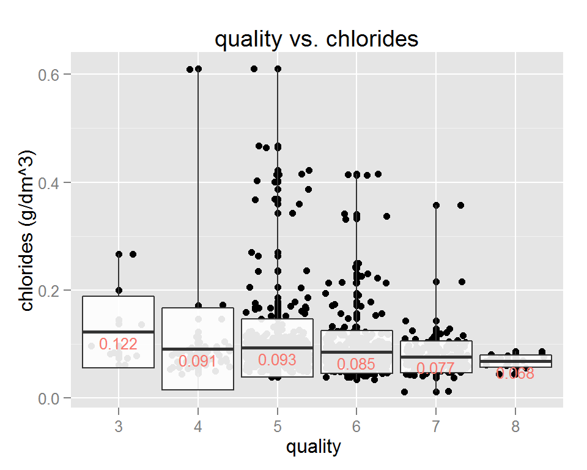

— The figure shows that not much differences among the mean of chlorides of each quality. The red wine with quality 8 has comparative smaller chlorides. The red wine with the lowest quality has the largest chlrides content.

### 6. quality against free.sulfur.dioxide, total.sulfur.dioxide, sulphates

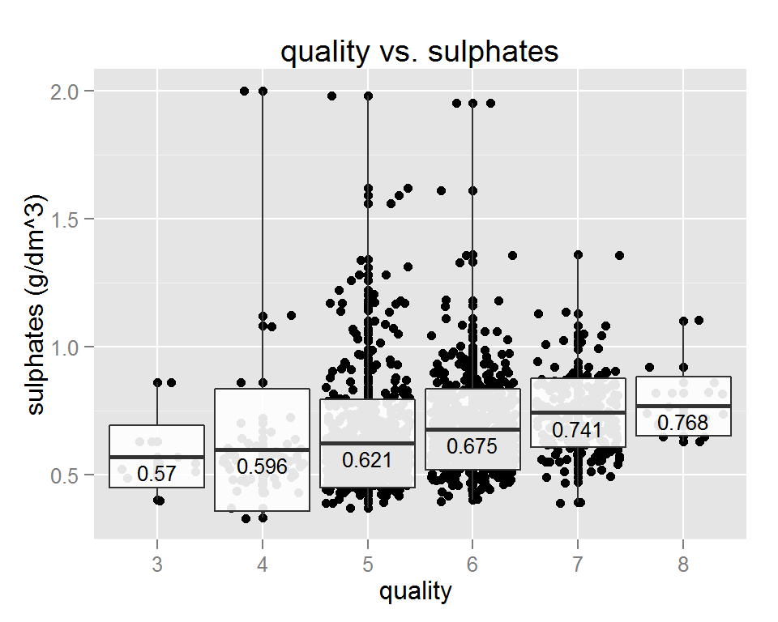

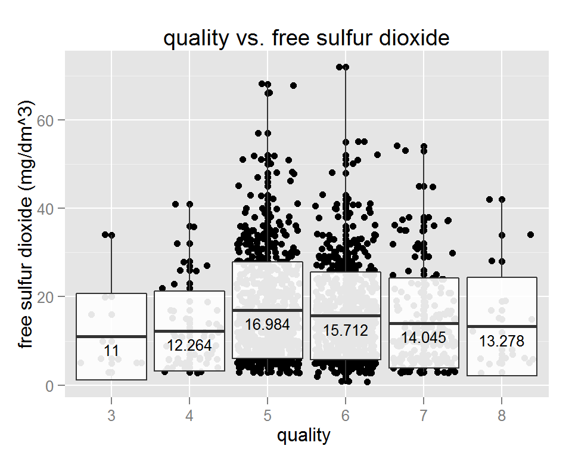

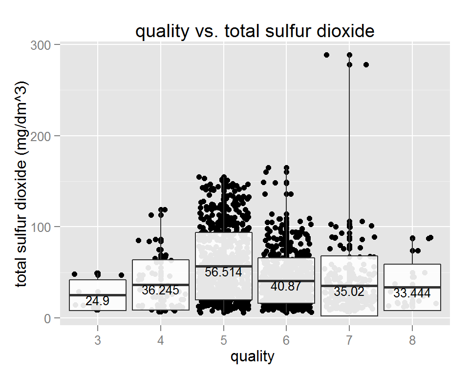

— The scatter plot of quality against sulphates show that high- quality red wine has higher mean sulphates.

### 7. quality against pH

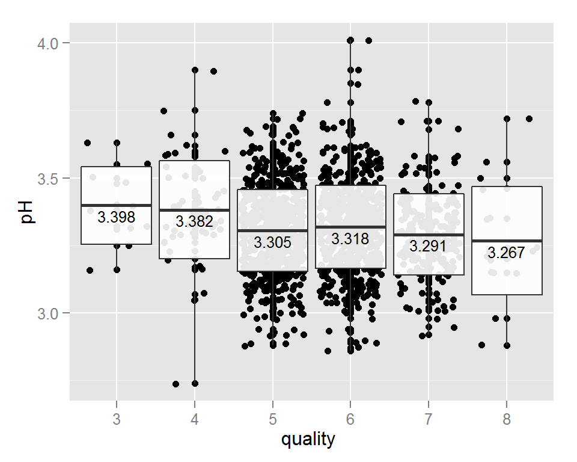

— The scatter plot of quality against ph shows the mean of ph for each quality score is quite the same. So I will not regard it importand factor for quality.

### 8. quality and density

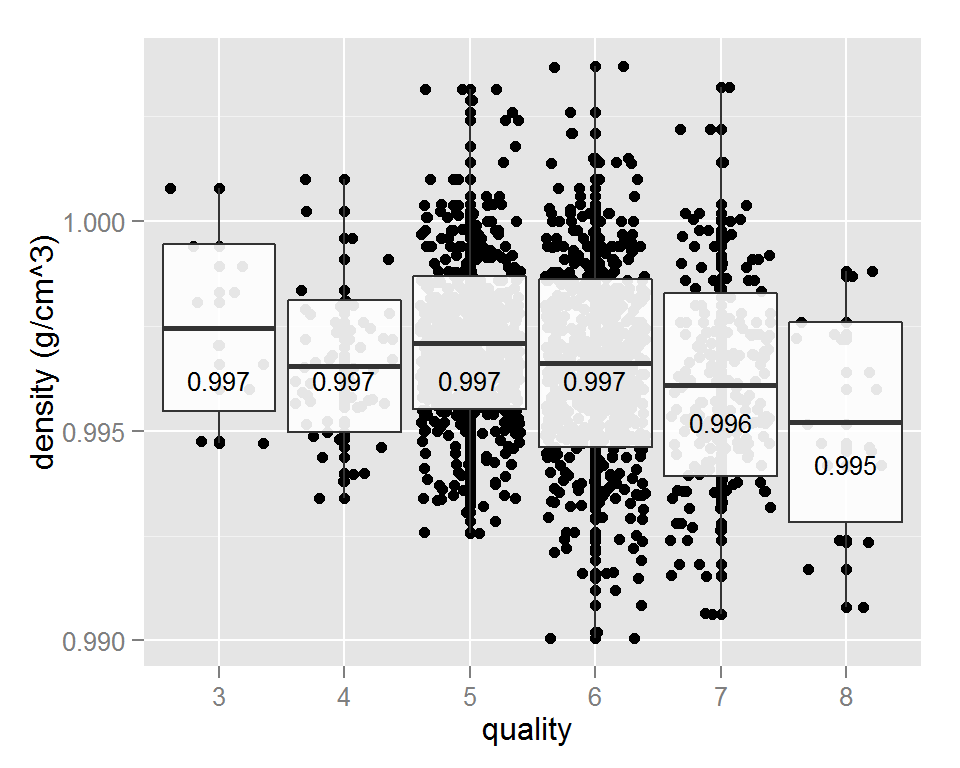

# Bivariate Analysis

### Did you observe any interesting relationships between the other features (not the main feature(s) of interest)?

```r
# check the correlation between volatile acidity and fixed acidity
cor.test(redwine$volatile.acidity, redwine$fixed.acidity)
```

```
    Pearson's product-moment correlation

data:  redwine$volatile.acidity and redwine$fixed.acidity
t = -10.589, df = 1597, p-value < 2.2e-16
alternative hypothesis: true correlation is not equal to 0
95 percent confidence interval:
 -0.3013681 -0.2097433
sample estimates:
       cor
-0.2561309
```

— According to the above investigation, features, like fixed acidity, residual sugar, chlorides, free sulfur dioxide, total sulfur dioxide, ph, are not strongly related to quality. In the scatter plot of quality against sulfur, one interesting discovery is that even though both sulfur dioxide and sulphates has element sulfur in the aspect of chemical composition, the effect on red wine quality is different. Very high quality and very low quality red wine has smaller sulfur dioxide than middle-ranked red wines. In contrast, higher sulphates usually means high-quality wine.

### What was the strongest relationship you found?

— The correlation coefficients between quality and volatile acidity, citric acid, sulphates, alcohol are -0.3906, 0.2264, 0.2514, 0.4762 respectively. The biggest absolute value is found between alcohol and quality. In the bivariate plotting, it is also found that quality is strongly related to alcohol. I need to further study the coupling effects among these four features, and whether they will strengthen or weaken eath others.

# Multivariate Plots Section

### Density plot of volatile.acidity, alcohol, citric.acid, sulphates group by quality

— According to previous analysis, four major features influencing quality are volatile acidity, citric acid, sulphates, alcohol. They are numeric variables. Use cut function to create ordered factor in order to investigate categoricall later. The code is as follow:

```r
# use cut to make categorical variable of volatile acidity
redwine$volatile.acidity.bucket <-
  cut(redwine$volatile.acidity, breaks=c(0.12,0.39, 0.52, 0.53, 0.64, 1.58))

# use cut to make categorical variable of citric acid
redwine$citric.acid.bucket <-
  cut(redwine$citric.acid, breaks=c(-0.01, 0.25, 0.50, 0.75, 1.0))

# use cut to make categorical variable of sulphates
redwine$sulphates.bucket <-
  cut(redwine$sulphates, breaks=c(0.33, 0.55, 0.62, 0.658, 0.73, 2.0))

# use cut to make categorical variable of alcohol
redwine$alcohol.bucket <-
  cut(redwine$alcohol, breaks = c(8.3, 9.9, 11.4, 12.9, 14.9))
```

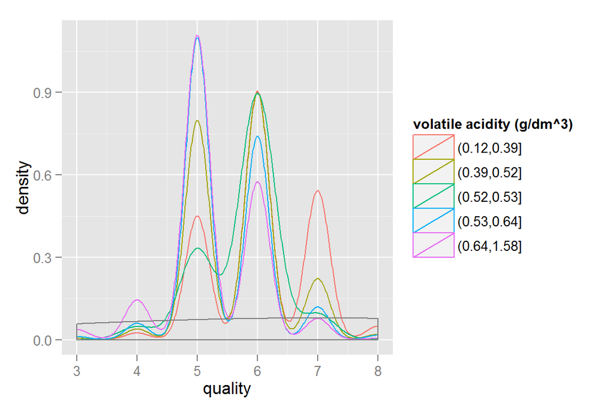

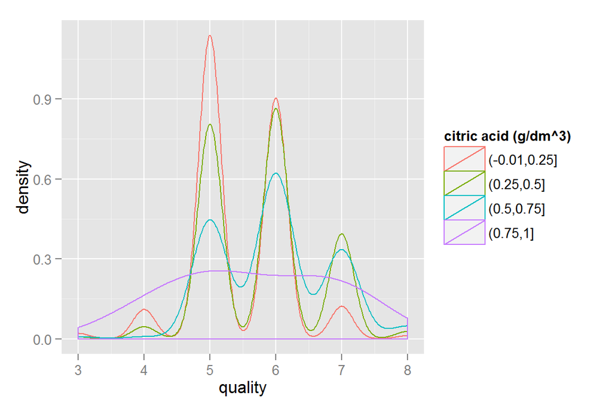

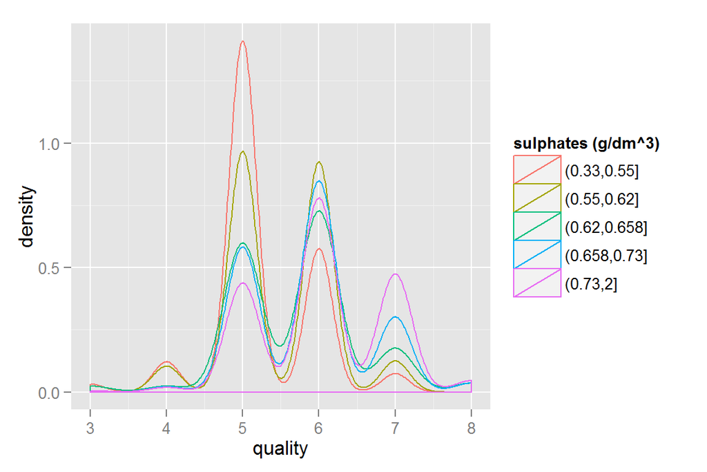

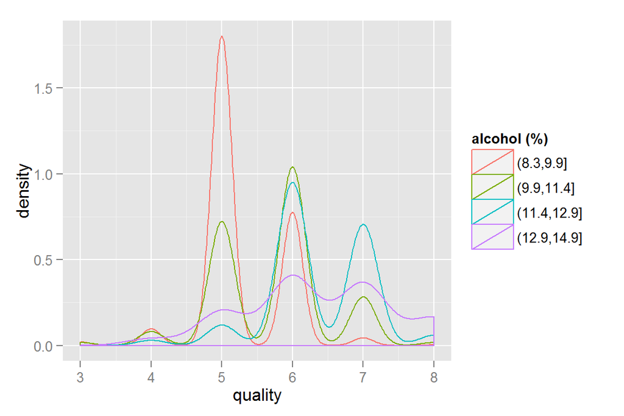

— It is observed in the density plots that wine of medium quality 5 more often fall into the range of low citric acid, low sulphates, and low alcohol than wine of quality 4 or 3. And red wine of quality 5 occur quite often in high volatile acidity.

### Investigate whether other features strengthen alcohol or not

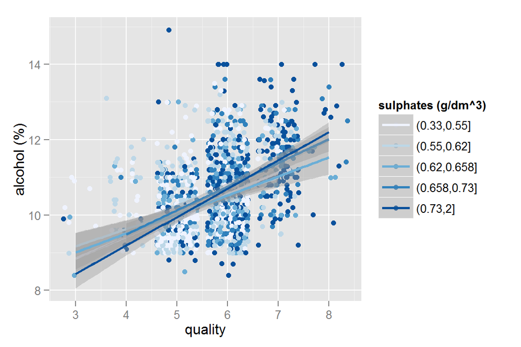

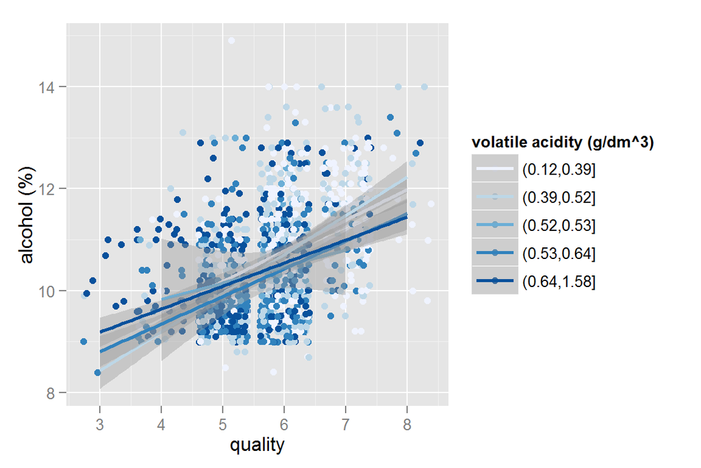

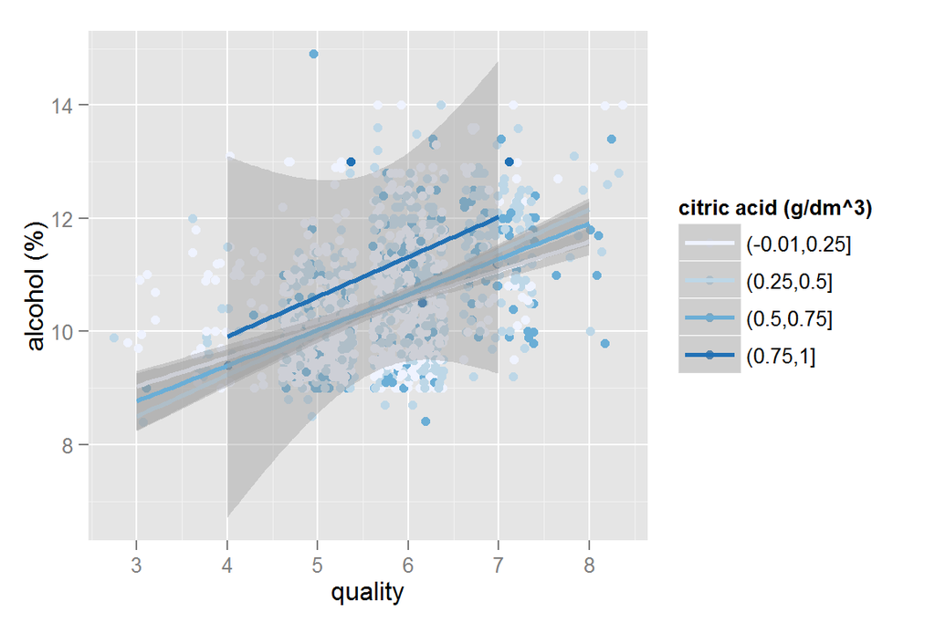

— The plot shows that higher quality wine has higher alcohol and also higher sulphates. Sulphates.bucket makes it more clear that high alcoohol could contribute to high quality of red wine.